# Bellabeat_case_study

# SCENARIO

You are a junior data analyst working on the marketing analyst team at Bellabeat, a high-tech manufacturer of health-focused products for women. Bellabeat is a successful small company, but they have the potential to become a larger player in the global smart device market. Urška Sršen, cofounder and Chief Creative Officer of Bellabeat, believes that analyzing smart device fitness data could help unlock new growth opportunities for the company. You have been asked to focus on one of Bellabeat’s products and analyze smart device data to gain insight into how consumers are using their smart devices. The insights you discover will then help guide marketing strategy for the company. You will present your analysis to the Bellabeat executive team along with your high-level recommendations for Bellabeat’s marketing strategy

## 1. Ask

The goal of this project is to define a new marketing strategy for Bellabeat company in order to grow the sales of its Smart devices. In order to do that, Smart devices data will be explored to have an overview of how the customers use these devices and have an idea of the user profile to address the marketing campaign. The analysis results will be presented to the company co founders.

## 2. Prepare

The dataset that will be used for the analysis is the following one:

The dataset is organized in different .csv files storing data about:

- Sleeping hours
- Activity
- Intensities
- Calories
- Weight
- Heartrate

There are minute, hour and daily level files. For the minute level files there are both the long and wide format.

As the dataset does not contain information about the users age and gender, I am going to consider that the samples have been taken randomly and they represent the whole population. Nevertheless, I will try to obtain a user profile from the analysis.

## 3. Process

We will use R for analysis and visualizatin. First of all, I have imported the different tables of the dataset: (before importing the dataset lets install and load all the important libraries:)

```r
install.packages("tidyverse")
install.packages("here")
install.packages("skimr")
install.packages("janitor")
install.packages("lubridate")
library(tidyverse)
library(here)
library(skimr)
library(janitor)
library(lubridate)
library(reshape2)
```

[output not shown]

NOW LETS TAKE A LOOK AT THE FOLLOWING TABLES:-

### Heart Rate

```r
skim_without_charts(heartrate)
```

```
── Data Summary ────────────────────────
                           Values
Name                       heartrate
Number of rows             2483658
Number of columns          3
_______________________
Column type frequency:
  character                1
  numeric                  2
________________________
Group variables            None

── Variable type: character ───────────────────────────────────────────────
  skim_variable n_missing complete_rate   min   max empty n_unique
1 Time                  0             1    19    21     0   961274
  whitespace
1          0

── Variable type: numeric ─────────────────────────────────────────────────
  skim_variable n_missing complete_rate         mean           sd
1 Id                    0             1 5513764629.  1950223761.
2 Value                 0             1         77.3         19.4
          p0        p25        p50        p75       p100
1 2022484408 4388161847 5553957443 6962181067 8877689391
2         36         63         73         88        203
```

```r
head(heartrate)
```

| Id | Time | Value |
| --- | --- | --- |
| 2022484408 | 4/12/2016 7:21:00 AM | 97 |
| 2022484408 | 4/12/2016 7:21:05 AM | 102 |
| 2022484408 | 4/12/2016 7:21:10 AM | 105 |
| 2022484408 | 4/12/2016 7:21:20 AM | 103 |
| 2022484408 | 4/12/2016 7:21:25 AM | 101 |
| 2022484408 | 4/12/2016 7:22:05 AM | 95 |

The table contains a numeric Id for the different users, a numeric value for the heart rate and the time of the measure with char format.

```r
heartrate %>%
  group_by(Id) %>%
  summarize(max_rate = max(Value),min_rate = min(Value), mean_rate = mean(Value))
```

| Id | max_rate | min_rate | mean_rate |
| --- | --- | --- | --- |
| 2022484408 | 203 | 38 | 80.23686 |
| 2026352035 | 125 | 63 | 93.77631 |
| 2347167796 | 195 | 49 | 76.72279 |
| 4020332650 | 191 | 46 | 82.30058 |
| 4388161847 | 180 | 39 | 66.13300 |
| 4558609924 | 199 | 44 | 81.67395 |
| 5553957443 | 165 | 47 | 68.63309 |
| 5577150313 | 174 | 36 | 69.56452 |
| 6117666160 | 189 | 52 | 83.74989 |
| 6775888955 | 177 | 55 | 92.02963 |

[output cut: 4 more lines]

```r
NA
```

Before transforming some inconsistent data, I have taken a quick look at the table. It has information about 14 users (less than the 50% of the population) but, as I think this data is important I will perform a reduced analysis of it. The normal average heart rate for adults is between 60 and 100 bpm, so it seems that the values are coherent.

I have arranged the columns names and time and date formats, so the result table is like the following one:

```r
heartrate_clean <- heartrate %>%
   rename_with(tolower) %>%
   rename(rate_value=value) %>%
   mutate(date=format(as.POSIXct(time, format="%m/%d/%Y %I:%M:%S %p", tz=Sys.timezone()), format = "%m/%d/%y")) %>%
   mutate(time=format(as.POSIXct(time, format="%m/%d/%Y %I:%M:%S %p", tz=Sys.timezone()), format = "%H:%M:%S"))
```

now the table will look like:

```r
head(heartrate_clean)
```

| id | time | rate_value | date |
| --- | --- | --- | --- |
| 2022484408 | 07:21:00 | 97 | 04/12/16 |
| 2022484408 | 07:21:05 | 102 | 04/12/16 |
| 2022484408 | 07:21:10 | 105 | 04/12/16 |
| 2022484408 | 07:21:20 | 103 | 04/12/16 |
| 2022484408 | 07:21:25 | 101 | 04/12/16 |
| 2022484408 | 07:22:05 | 95 | 04/12/16 |

### Sleep Records

```r
skim_without_charts(sleep)
```

```
── Data Summary ────────────────────────
                           Values
Name                       sleep
Number of rows             413
Number of columns          5
_______________________
Column type frequency:
  character                1
  numeric                  4
________________________
Group variables            None

── Variable type: character ───────────────────────────────────────────────
  skim_variable n_missing complete_rate   min   max empty n_unique
1 SleepDay              0             1    20    21     0       31
  whitespace
1          0

── Variable type: numeric ─────────────────────────────────────────────────
  skim_variable      n_missing complete_rate          mean      sd
1 Id                         0             1 5000979403.   2.06e+9
2 TotalSleepRecords          0             1          1.12 3.46e-1
3 TotalMinutesAsleep         0             1        419.   1.18e+2
4 TotalTimeInBed             0             1        459.   1.27e+2
          p0        p25        p50        p75       p100
1 1503960366 3977333714 4702921684 6962181067 8792009665
2          1          1          1          1          3
3         58        361        433        490        796
4         61        403        463        526        961
```

```r
head(sleep)
```

| Id | SleepDay | TotalSleepRecords | TotalMinutesAsleep | TotalTimeInBed |
| --- | --- | --- | --- | --- |
| 1503960366 | 4/12/2016 12:00:00 AM | 1 | 327 | 346 |
| 1503960366 | 4/13/2016 12:00:00 AM | 2 | 384 | 407 |
| 1503960366 | 4/15/2016 12:00:00 AM | 1 | 412 | 442 |
| 1503960366 | 4/16/2016 12:00:00 AM | 2 | 340 | 367 |
| 1503960366 | 4/17/2016 12:00:00 AM | 1 | 700 | 712 |
| 1503960366 | 4/19/2016 12:00:00 AM | 1 | 304 | 320 |

The table contains a numeric Id for the different users, a numeric double value for the sleep records and the time of the measure with char format.

```r
sleep%>%
   group_by(Id) %>%
   summarize(max_asleep = max(TotalMinutesAsleep),min_asleep = min(TotalMinutesAsleep), mean_asleep = mean(TotalMinutesAsleep))
```

| Id | max_asleep | min_asleep | mean_asleep |
| --- | --- | --- | --- |
| 1503960366 | 700 | 245 | 360.2800 |
| 1644430081 | 796 | 119 | 294.0000 |
| 1844505072 | 722 | 590 | 652.0000 |
| 1927972279 | 750 | 166 | 417.0000 |
| 2026352035 | 573 | 357 | 506.1786 |
| 2320127002 | 61 | 61 | 61.0000 |
| 2347167796 | 556 | 374 | 446.8000 |
| 3977333714 | 424 | 152 | 293.6429 |
| 4020332650 | 501 | 77 | 349.3750 |
| 4319703577 | 692 | 59 | 476.6538 |

[output cut: 14 more lines]

```r
NA
```

It has information about 24 users (more than the 70% of the population) but there are only 15 users that have more than 15 observations, which represent the 50% of the time range analyzed.

It can be observed that some users have really short sleep records some days, which is not normal and seem to be bad lectures, so I am going to discard the sleep records under 4h. I have also checked if there are records with less time in bed than asleep minutes but it seems that there are not errors like that. After arranging the time to date format and discarding some observations, the table looks like this:

```r
sleep_clean <- sleep %>%
   rename_with(tolower) %>%
   clean_names() %>%
   rename(date=sleepday,sleep_records=totalsleeprecords,minutes_asleep=totalminutesasleep,time_bed=totaltimeinbed) %>%
   mutate(date=format(as.POSIXct(date, format="%m/%d/%Y %I:%M:%S %p", tz=Sys.timezone()), format = "%m/%d/%y")) %>%
   filter(minutes_asleep>240)
```

### Activity Records

```r
skim_without_charts(activity)
```

```
── Data Summary ────────────────────────
                           Values
Name                       activity
Number of rows             940
Number of columns          15
_______________________
Column type frequency:
  character                1
  numeric                  14
________________________
Group variables            None

── Variable type: character ───────────────────────────────────────────────
  skim_variable n_missing complete_rate   min   max empty n_unique
1 ActivityDate          0             1     8     9     0       31
  whitespace
1          0

── Variable type: numeric ─────────────────────────────────────────────────
   skim_variable            n_missing complete_rate    mean      sd
 1 Id                               0             1 4.86e+9 2.42e+9
 2 TotalSteps                       0             1 7.64e+3 5.09e+3
 3 TotalDistance                    0             1 5.49e+0 3.92e+0
 4 TrackerDistance                  0             1 5.48e+0 3.91e+0
 5 LoggedActivitiesDistance         0             1 1.08e-1 6.20e-1
 6 VeryActiveDistance               0             1 1.50e+0 2.66e+0
 7 ModeratelyActiveDistance         0             1 5.68e-1 8.84e-1
 8 LightActiveDistance              0             1 3.34e+0 2.04e+0
 9 SedentaryActiveDistance          0             1 1.61e-3 7.35e-3
10 VeryActiveMinutes                0             1 2.12e+1 3.28e+1
11 FairlyActiveMinutes              0             1 1.36e+1 2.00e+1
12 LightlyActiveMinutes             0             1 1.93e+2 1.09e+2
13 SedentaryMinutes                 0             1 9.91e+2 3.01e+2
14 Calories                         0             1 2.30e+3 7.18e+2
           p0           p25     p50     p75    p100
 1 1503960366 2320127002    4.45e+9 6.96e+9 8.88e+9
 2          0       3790.   7.41e+3 1.07e+4 3.60e+4
 3          0          2.62 5.24e+0 7.71e+0 2.80e+1
 4          0          2.62 5.24e+0 7.71e+0 2.80e+1
 5          0          0    0       0       4.94e+0
 6          0          0    2.10e-1 2.05e+0 2.19e+1
 7          0          0    2.40e-1 8.00e-1 6.48e+0
 8          0          1.95 3.36e+0 4.78e+0 1.07e+1
 9          0          0    0       0       1.10e-1
10          0          0    4   e+0 3.2 e+1 2.1 e+2
11          0          0    6   e+0 1.9 e+1 1.43e+2
12          0        127    1.99e+2 2.64e+2 5.18e+2
13          0        730.   1.06e+3 1.23e+3 1.44e+3
14          0       1828.   2.13e+3 2.79e+3 4.9 e+3
```

```r
activity  %>%
  group_by(Id) %>%
   summarize(max_steps = max(TotalSteps),min_steps = min(TotalSteps), mean_steps = mean(TotalSteps))
```

| Id | max_steps | min_steps | mean_steps |
| --- | --- | --- | --- |
| 1503960366 | 18134 | 0 | 12116.742 |
| 1624580081 | 36019 | 1510 | 5743.903 |
| 1644430081 | 18213 | 1223 | 7282.967 |
| 1844505072 | 8054 | 0 | 2580.065 |
| 1927972279 | 3790 | 0 | 916.129 |
| 2022484408 | 18387 | 3292 | 11370.645 |
| 2026352035 | 12357 | 254 | 5566.871 |
| 2320127002 | 10725 | 772 | 4716.871 |
| 2347167796 | 22244 | 42 | 9519.667 |
| 2873212765 | 9685 | 2524 | 7555.774 |

[output cut: 23 more lines]

```r
NA
```

The table contains a numeric Id for the different users, numeric values for the activity observations and the time .

It is clearly seen that their are no null records. Also their are some columns which is incorrectly formatted like Activity. I am also going to ignore these observations that present a total of daily steps under 100, as all persons have some little activity every day. I am not going to analyse the different intensities distances, but the time. The result table for analysis is the following one:

```r
activity_clean <- activity %>%
   select(Id, ActivityDate, TotalSteps, TotalDistance, VeryActiveMinutes, FairlyActiveMinutes, LightlyActiveMinutes, SedentaryMinutes, Calories) %>%
   rename_with(tolower) %>%
   clean_names() %>%
   rename(date=activitydate,total_steps=totalsteps,total_distance=totaldistance,very_active_min=veryactiveminutes,fairly_active_min=fairlyactiveminutes,lightly_active_min=lightlyactiveminutes,sedentary_min=sedentaryminutes) %>%
   mutate(date=format(as.POSIXct(date, format="%m/%d/%Y", tz=Sys.timezone()), format = "%m/%d/%y")) %>%
   filter(total_steps>100)
```

## 4. Analyze and 5. Share

First of all, I am going to transform the heart rate table to have daily records instead of seconds values and allow me to merge and compare these observations with the other tables.

As the heart rate dataset has less users than the others, I am going to merge first the sleep and activity observations.

```r
daily_activity_merged <- merge(sleep_clean, activity_clean, by=c('id', 'date'))
 head(daily_activity_merged)
```

|  | id | date | sleep_records | minutes_asleep | time_bed | total_steps | total_distance | very_active_min | fairly_active_min | lightly_active_min | sedentary_min | calories |
| --- | --- | --- | --- | --- | --- | --- | --- | --- | --- | --- | --- | --- |
| 1 | 1503960366 | 04/12/16 | 1 | 327 | 346 | 13162 | 8.50 | 25 | 13 | 328 | 728 | 1985 |
| 2 | 1503960366 | 04/13/16 | 2 | 384 | 407 | 10735 | 6.97 | 21 | 19 | 217 | 776 | 1797 |
| 3 | 1503960366 | 04/15/16 | 1 | 412 | 442 | 9762 | 6.28 | 29 | 34 | 209 | 726 | 1745 |
| 4 | 1503960366 | 04/16/16 | 2 | 340 | 367 | 12669 | 8.16 | 36 | 10 | 221 | 773 | 1863 |
| 5 | 1503960366 | 04/17/16 | 1 | 700 | 712 | 9705 | 6.48 | 38 | 20 | 164 | 539 | 1728 |
| 6 | 1503960366 | 04/19/16 | 1 | 304 | 320 | 15506 | 9.88 | 50 | 31 | 264 | 775 | 2035 |

```r
NA
```

Let’s take a quick look at the table statistics:

```r
summary(daily_activity_merged)
```

```
       id                date           sleep_records   minutes_asleep
 Min.   :1.504e+09   Length:381         Min.   :1.000   Min.   :245.0
 1st Qu.:3.977e+09   Class :character   1st Qu.:1.000   1st Qu.:383.0
 Median :4.703e+09   Mode  :character   Median :1.000   Median :441.0
 Mean   :5.066e+09                      Mean   :1.126   Mean   :442.1
 3rd Qu.:6.962e+09                      3rd Qu.:1.000   3rd Qu.:498.0
 Max.   :8.792e+09                      Max.   :3.000   Max.   :796.0
    time_bed      total_steps    total_distance   very_active_min
 Min.   :257.0   Min.   :  254   Min.   : 0.160   Min.   :  0.00
 1st Qu.:417.0   1st Qu.: 5325   1st Qu.: 3.620   1st Qu.:  0.00
 Median :471.0   Median : 8954   Median : 6.370   Median :  9.00
 Mean   :480.9   Mean   : 8560   Mean   : 6.051   Mean   : 25.71
 3rd Qu.:535.0   3rd Qu.:11193   3rd Qu.: 7.920   3rd Qu.: 38.00
 Max.   :961.0   Max.   :22770   Max.   :17.540   Max.   :210.00
 fairly_active_min lightly_active_min sedentary_min       calories
 Min.   :  0.00    Min.   : 17.0      Min.   : 125.0   Min.   : 741
 1st Qu.:  0.00    1st Qu.:159.0      1st Qu.: 623.0   1st Qu.:1861
 Median : 11.00    Median :209.0      Median : 711.0   Median :2220
 Mean   : 16.92    Mean   :219.3      Mean   : 693.3   Mean   :2410
 3rd Qu.: 26.00    3rd Qu.:266.0      3rd Qu.: 772.0   3rd Qu.:2924
 Max.   :116.00    Max.   :518.0      Max.   :1058.0   Max.   :4900
```

With this first summary it can be observed that:

- The users sleep an average of 7.3 hours and are in bed an average of 8 hours.
- The users walk an average of 8000 steps and 6 Km, which is the recommended.
- The average sedentary time of the users is around 11 hours, which seems a lot, and 40 min of active time.

I am going to first compare the total steps with different activity parameters.

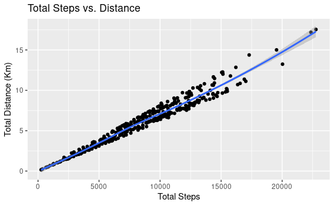

```r
ggplot(data=daily_activity_merged, aes(x=total_steps, y=total_distance)) +
  geom_point() + geom_smooth() + labs(title="Total Steps vs. Distance",x="Total Steps" ,y="Total Distance (Km)" )
```

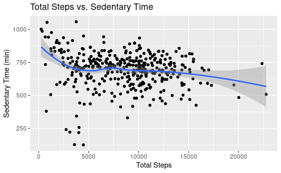

```r
ggplot(data=daily_activity_merged, aes(x=total_steps, y=sedentary_min)) +
  geom_point() + geom_smooth() + labs(title="Total Steps vs. Sedentary Time",x="Total Steps" ,y="Sedentary Time (min)" )
```

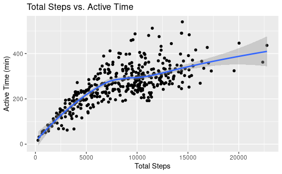

```r
ggplot(data=daily_activity_merged, aes(x=total_steps, y=very_active_min+fairly_active_min+lightly_active_min)) +
  geom_point() + geom_smooth() + labs(title="Total Steps vs. Active Time",x="Total Steps" ,y="Active Time (min)" )
```

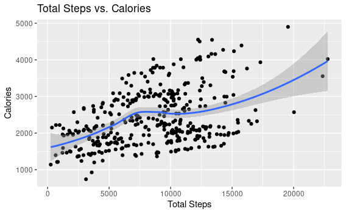

```r
ggplot(data=daily_activity_merged, aes(x=total_steps, y=calories)) +
  geom_point() + geom_smooth() + labs(title="Total Steps vs. Calories",x="Total Steps" ,y="Calories" )
```

The number of steps taken by a user daily is proportional with the walked distance as expected. It seems that the active time also increases with the steps taken but it’s not as linear and the same happens with the calories. In the case of the sedentary time, it shows an inverse relation with the steps but it’s very scattered.

Let’s see which relationships appear comparing the active time with the sedentary time and calories.

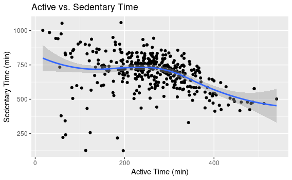

```r
ggplot(data=daily_activity_merged, aes(x=very_active_min+fairly_active_min+lightly_active_min, y=sedentary_min)) +
  geom_point() + geom_smooth() + labs(title="Active vs. Sedentary Time",x="Active Time (min)" ,y="Sedentary Time (min)" )
```

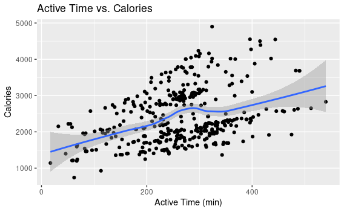

```r
ggplot(data=daily_activity_merged, aes(x=very_active_min+fairly_active_min+lightly_active_min, y=calories)) +
  geom_point() + geom_smooth() + labs(title="Active Time vs. Calories",x="Active Time (min)" ,y="Calories" )
```

It is also expected that the sedentary time decreases when the active time is higher and the calories increase with the active time.

Now that we have checked that the activity trends are the expected ones, let’s see which relationship appears between the sleep time and the activity time.

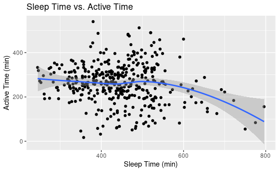

```r
ggplot(data=daily_activity_merged, aes(x=minutes_asleep, y=very_active_min+fairly_active_min+lightly_active_min)) +
  geom_point() + geom_smooth() + labs(title="Sleep Time vs. Active Time",x="Sleep Time (min)" ,y="Active Time (min)" )
```

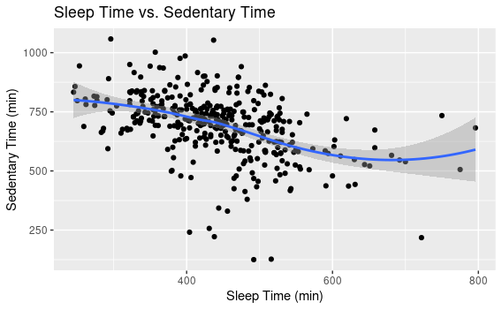

```r
ggplot(data=daily_activity_merged, aes(x=minutes_asleep, y=sedentary_min)) +
  geom_point() + geom_smooth() + labs(title="Sleep Time vs. Sedentary Time",x="Sleep Time (min)" ,y="Sedentary Time (min)" )
```

From these plots we can observe that users who sleep over 10 hours are less active and a bit more sedentary. Sleeping under 10 hours does not present a direct relation with the active time but it seems that the sedentary lifestyle decreases when users sleep up to 10 hours.

Let’s take a look at the heart rate statistics:

```r
heartrate_hour <- heartrate_clean %>%
   mutate(time=format(strptime(time,"%H:%M:%S"),'%H:00:00')) %>%
   group_by(id, date, time) %>%
   summarize(rate_value=mean(rate_value))
```

```r
summary_heartrate_hour <- heartrate_hour %>%
   group_by(time) %>%
   summarize(avg_rate = mean(rate_value),min_rate = min(rate_value), max_rate = max(rate_value))
```

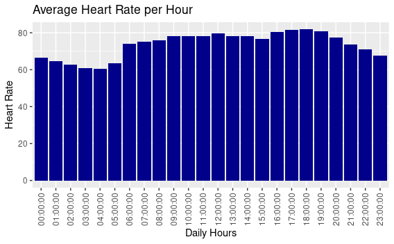

```r
ggplot(data=summary_heartrate_hour, aes(x=time,y=avg_rate)) +
  geom_bar(stat="identity", fill='darkblue') + labs(title="Average Heart Rate per Hour",x="Daily Hours" ,y="Heart Rate" ) +
  theme(axis.text.x = element_text(angle = 90, vjust = 0.5, hjust=1))
```

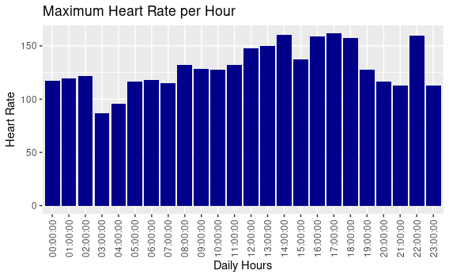

```r
ggplot(data=summary_heartrate_hour, aes(x=time,y=max_rate)) +
  geom_bar(stat="identity", fill='darkblue') + labs(title="Maximum Heart Rate per Hour",x="Daily Hours" ,y="Heart Rate" ) +
  theme(axis.text.x = element_text(angle = 90, vjust = 0.5, hjust=1))
```

The average Heart Rate makes sense, as it presents lower values for the sleeping hours (from 23:00 to 5:00). The higher maximum rates appear during the morning (from 12:00 to 14:00), the afternoon (from 16:00 to 18:00) and at the evening (22:00) which can be the time ranges at which the users exercise.

Let’s now merge the daily average heart rates with the activity table.

```r
heartrate_daily <- heartrate_clean %>%
   group_by(id,date) %>%
   summarize(max_rate = max(rate_value),min_rate = min(rate_value), mean_rate = mean(rate_value))
```

```r
daily_merged <- merge(daily_activity_merged, heartrate_daily , by=c('id', 'date'))
head(daily_merged)
```

|  | id | date | sleep_records | minutes_asleep | time_bed | total_steps | total_distance | very_active_min | fairly_active_min | lightly_active_min | sedentary_min | calories | max_rate | min_rate | mean_rate |
| --- | --- | --- | --- | --- | --- | --- | --- | --- | --- | --- | --- | --- | --- | --- | --- |
| 1 | 2026352035 | 04/17/16 | 1 | 437 | 498 | 838 | 0.52 | 0 | 0 | 60 | 1053 | 1214 | 80 | 63 | 68.65625 |
| 2 | 2026352035 | 04/25/16 | 1 | 506 | 531 | 6017 | 3.73 | 0 | 0 | 260 | 821 | 1576 | 125 | 70 | 99.50581 |
| 3 | 2026352035 | 05/02/16 | 1 | 511 | 543 | 7018 | 4.35 | 0 | 0 | 355 | 716 | 1690 | 122 | 70 | 84.13457 |
| 4 | 2026352035 | 05/09/16 | 1 | 531 | 556 | 10685 | 6.62 | 0 | 0 | 401 | 543 | 1869 | 123 | 70 | 98.23390 |
| 5 | 2347167796 | 04/13/16 | 1 | 467 | 531 | 10352 | 7.01 | 19 | 32 | 195 | 676 | 2038 | 158 | 55 | 73.81290 |
| 6 | 2347167796 | 04/14/16 | 1 | 445 | 489 | 10129 | 6.70 | 1 | 48 | 206 | 705 | 2010 | 154 | 52 | 72.57948 |

```r
NA
```

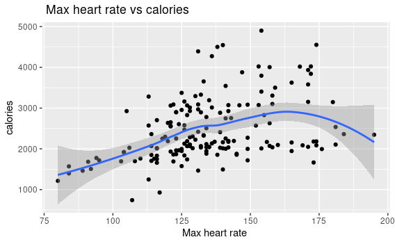

```r
ggplot(data=daily_merged, aes(x=max_rate, y=calories)) +
  geom_point() + geom_smooth() + labs(title=" Max heart rate vs calories",x="Max heart rate " ,y="calories" )
```

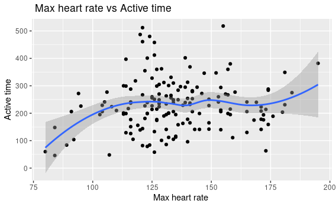

```r
ggplot(data=daily_merged, aes(x=max_rate, y=lightly_active_min
)) +
  geom_point() + geom_smooth() + labs(title=" Max heart rate vs Active time",x="Max heart rate " ,y="Active time" )
```

Let’s finally analyse which percentage of the day users usually spend for each type of activity.

```r
daily_activity_summary <- daily_merged %>%
   summarise(time_in_bed = mean(time_bed), sedentary_minutes = mean(sedentary_min), lightly_active_minutes = mean(lightly_active_min), fairly_active_minutes = mean(fairly_active_min), very_active_minutes = mean(very_active_min))
```

```r
daily_summary_long <- daily_activity_summary*100/(daily_activity_summary$time_in_bed + daily_activity_summary$sedentary_minutes + daily_activity_summary$lightly_active_minutes + daily_activity_summary$fairly_active_minutes + daily_activity_summary$very_active_minutes)
```

```r
gather(daily_summary_long)
```

| key | value |
| --- | --- |
| time_in_bed | 33.597678 |
| sedentary_minutes | 47.192688 |
| lightly_active_minutes | 16.095865 |
| fairly_active_minutes | 1.152028 |
| very_active_minutes | 1.961741 |

```r
daily_summ_long <- gather(daily_summary_long)
```

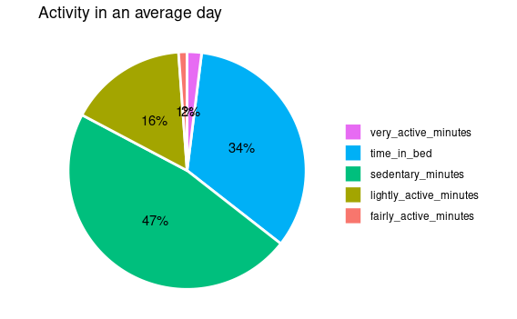

```r
ggplot(daily_summ_long, aes(x="", y=value, fill=factor(key))) +
  geom_bar(width = 1, size = 1, color = "white", stat = "identity") +
  coord_polar("y", start=0) +
geom_text(aes(label = paste0(round(value), "%")),
              position = position_stack(vjust = 0.5)) +
    labs(x = NULL, y = NULL, fill = NULL,
         title = "Activity in an average day") +
  guides(fill = guide_legend(reverse = TRUE)) +
  theme_void()
```

On average, users spend 47% of the day doing sedentary activities and a 34% in bed, which leaves only 19% of real activity time.

## 6. Act

Now on the basis of my data analysis I have found that :-

It seems that the average users are adult people, who work or study in static positions (which implies sitting a lot of hours), and exercise in their free time.

Bellabeat marketing strategy can be focused on showing to women the advantages of having knowledge of its healthy lifestyle.